# Organic Contaminants in Great Lakes Tributaries: Watersheds and Chemicals of Greatest Concern

Wednesday, May 27, 2015

## Multi-agency team

- USEPA
  - Great Lakes National Program Office
  - Mid-Continent Ecology Division, Duluth, MN
    - Tony Schroeder, Dan Villeneuve, Brett Blackwell, Gary Ankley
  - Ecosystems Research Division, Athens, GA
  - National Center for Computational Toxicolgy
- Fish and Wildlife Service
- NOAA Mussel Watch
- U.S. Army Corps of Engineers
- USGS
  - WI, OH, NY, MN, and MI Water Science Centers
  - Columbia Environmental Research Center
  - Upper Mississippi Environmental Science Center
- St. Cloud University

## Overview

- Sampled Great Lakes Tributaries
  - 2010-2013: Multiple trace organic compounds
  - Sampling methods: Water samples and passive samplers
- Evaluating adverse biological effect potential based on chemistry results
  - Sites with greatest potential
  - Chemicals with greatest potential
- Different methods for biological effect evaluation
  - ToxCast-based evaluation
  - Water quality guideline-based evaluation
  - Comparison of these two methods

## Study sites: Tributaries

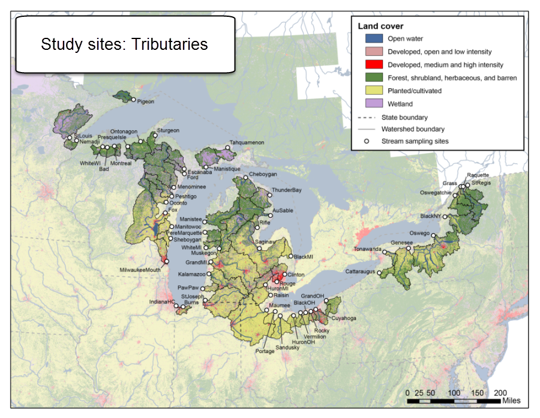

## Water quality data collected

| Water Samples: Organic Waste Compounds | Passive Samples |
| --- | --- |
| PAHs (6) | PAHs (33) |
| Insecticides (6) | Organic Waste Compounds (53) |
| Herbicides (7) | Organochlorine Pesticides (32) |
| Fire retardants (4) | PBDEs (5) |
| Pharmaceuticals (3) | Pharmaceuticals (31) |
| Plasticizers (5) | PCB (sum of total) |
| Detergent metabolites (8) |  |
| Antimicrobial disinfectants (3) |  |
| Solvents (2) |  |
| Fuels (4) |  |
| Dye/pigments (1) |  |
| Flavors & fragrances (10) |  |
| Sterols (4) |  |
| Misc (3) |  |

## Screening Endpoints Used in Analysis

- ToxCast:
  - "High throughput screening assays"
    - Expose living cells or isolated protiens
    - Screens for potential adverse biological effects
    - Much is focused on gaining information on biological pathways
  - 1860 compounds
  - 821 endpoints
  - AC50 used for this analysis (concentration at which activity is 50% of its maximum)
  - Exposure Activity Ratio (EAR) = concentration / AC50
- Water quality guidelines
  - Water sample analysis (not complete for passive samplers yet)
    - Established water quality guidelines
      - USEPA
      - Canadian Council of Ministers of the Environment
      - USGS
      - Literature

## Screening Endpoints Matches

- ToxCast
  - Water samples
    - 39 compounds of 64 total
    - Herbicide, Pharmaceuticals, Flavor/fragrance, PAH, Plasticizer, Insecticide, Other, Solvent, Fire Retardant, Antioxidant, Detergent Metabolites, Fuel, Antimicrobial Disinfectant
  - Passive samplers
    - 51 compounds of 162 total
    - PAHs, Pharmaceuticals, Other, Detergent metabolites, Flavor/Fragrance, Herbicide, Insecticide, OC Pesticides, Plasticizer, Solvent, Antimicrobial disinfectant
- Water Quality Guidelines
  - Water samples
    - 24 compounds of 64 total
    - PAH, Herbicide, Insecticide, Fuel, Plasticizer, Solvent, Other
  - Passive samplers
    - Not yet complete

## ToxCast: Water Sample Chemical Summary

| Chemical | Class | Fraction of Hits Per Site | Maximum EAR | Number End Points | Sites With Hits | Total Samples |
| --- | --- | --- | --- | --- | --- | --- |
| Metolachlor | Herbicide | 0.482142857142857 | 2082.32714246323 | 9 | 27 | 704 |
| Atrazine | Herbicide | 0.403508771929825 | 74.3497538365518 | 16 | 23 | 709 |
| Caffeine | Pharmaceuticals | 0.368421052631579 | 3.60466874573325 | 2 | 21 | 709 |
| Benzophenone | Flavor/fragrance | 0.298245614035088 | 2.03327696876451 | 4 | 17 | 709 |
| Naphthalene | PAH | 0.298245614035088 | 11.9415877290245 | 10 | 17 | 709 |
| Diethyl phthalate | Plasticizer | 0.280701754385965 | 1.00429369275916 | 3 | 16 | 707 |
| Cotinine | Pharmaceuticals | 0.192982456140351 | 11.3595961078719 | 3 | 11 | 703 |
| Triphenyl phosphate | Plasticizer | 0.192982456140351 | 0.603708685784925 | 2 | 11 | 703 |
| Carbaryl | Insecticide | 0.12280701754386 | 1.50066778493156 | 3 | 7 | 709 |
| Bromacil | Herbicide | 0.105263157894737 | 0.248929690204054 | 2 | 6 | 709 |

[output cut: 29 more lines]

## ToxCast: Water Sample Site Summary

| Station Name | Fraction of Hits Per Samples | Total Samples | Number of Chemicals With Hits | Number End Points | Maximum EAR | Ag [%] | Urban [%] |
| --- | --- | --- | --- | --- | --- | --- | --- |
| Portage | 0.984375 | 64 | 8 | 36 | 2082.32714246323 | 0.84 | 0.09 |
| Maumee | 1 | 64 | 10 | 32 | 825.989766510414 | 0.79 | 0.1 |
| Raisin | 0.977272727272727 | 44 | 10 | 28 | 607.345416551775 | 0.68 | 0.11 |
| Manitowoc | 0.837209302325581 | 43 | 5 | 14 | 534.463966565562 | 0.7 | 0.07 |
| MilwaukeeMouth | 0.955555555555556 | 45 | 12 | 29 | 513.64069514093 | 0.44 | 0.29 |
| StJoseph | 0.84 | 25 | 5 | 18 | 395.642157068013 | 0.584 | 0.142 |
| Clinton | 0.953488372093023 | 43 | 18 | 44 | 347.054523743871 | 0.21 | 0.51 |
| Genesee | 1 | 14 | 3 | 12 | 249.879257095587 | 0.46 | 0.09 |
| Saginaw | 0.967741935483871 | 31 | 10 | 21 | 152.703990447303 | 0.44 | 0.12 |
| HuronOH | 1 | 2 | 4 | 10 | 124.939628547794 | 0.75 | 0.09 |

[output cut: 47 more lines]

## ToxCast: Water Samples Map

**Color:** Maximum EAR  
**Size:** Number of chemicals with hits (0-19)

[interactive chart not shown]

## ToxCast: Passive Data Map

**Color:** Maximum EAR  
**Size:** Number of chemicals with hits (0-3)

[interactive chart not shown]

## Water Quality Guidelines Results

**Color:** Maximum EAR  
**Size:** Number of chemicals with hits (0-10)

[interactive chart not shown]

## ToxCast Regression Tree Model: Number of chemicals with hits

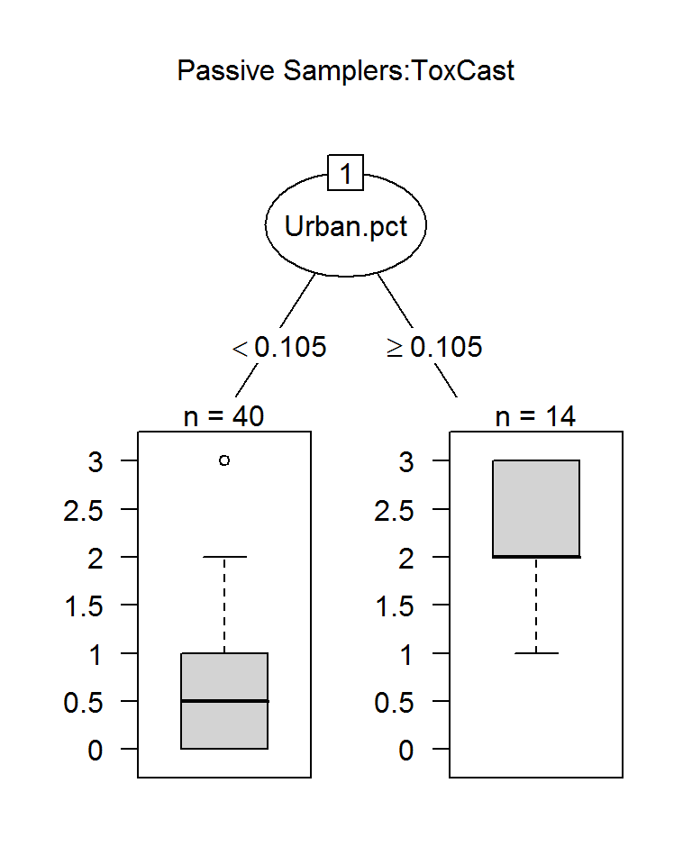

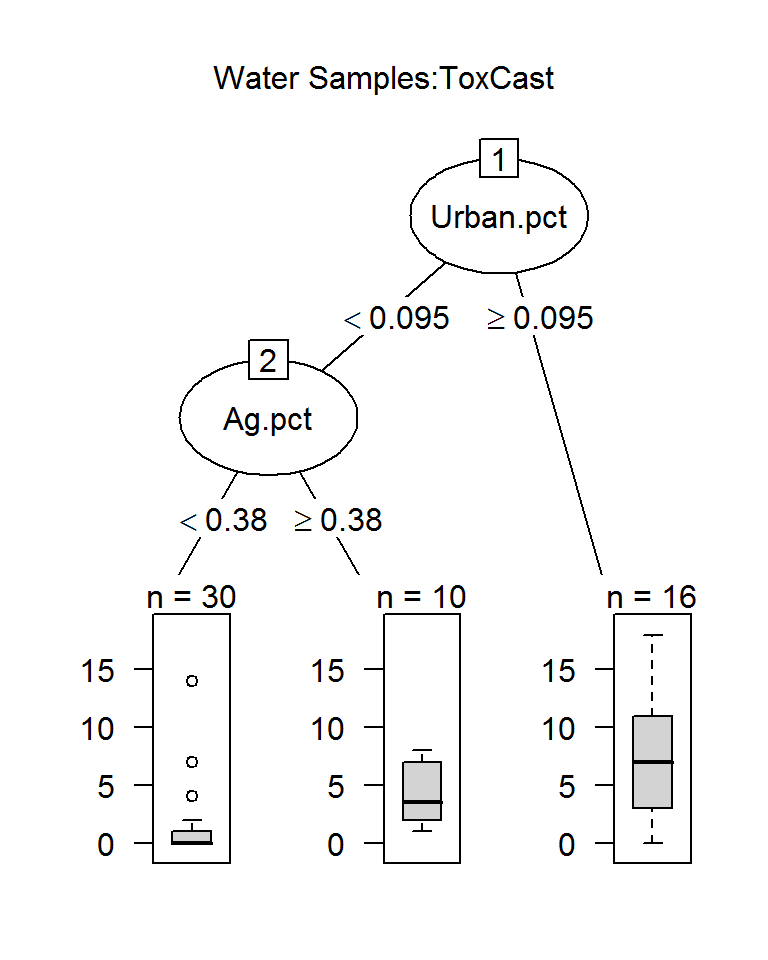

## Comparing ToxCast to WQGs: Number of chemicals with hits

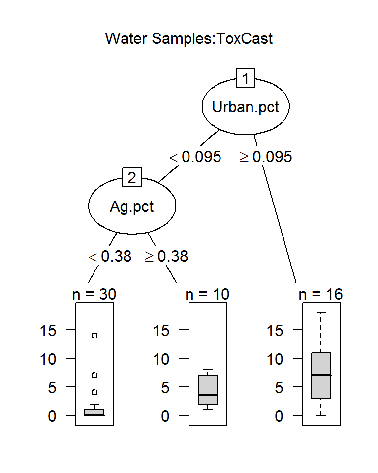

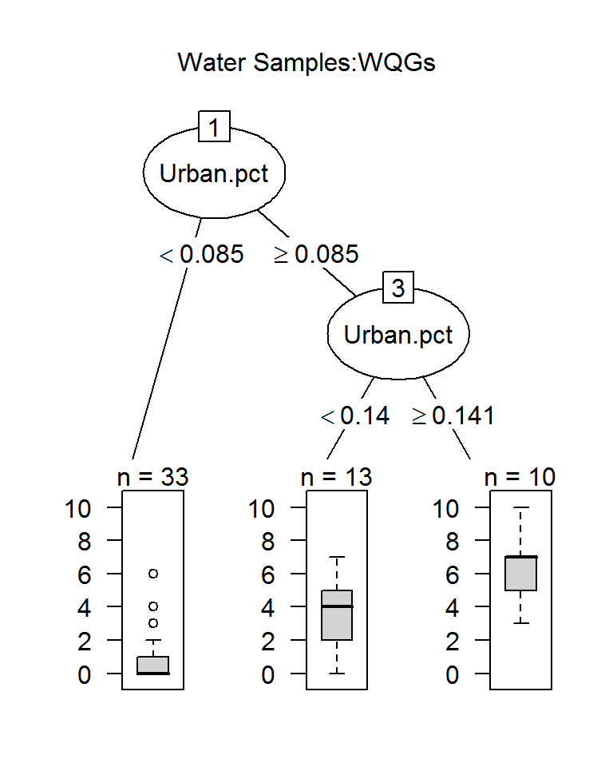

## Comparisons

| ToxCast | ToxCast | WQG |
| --- | --- | --- |
| Water Samples | Passive Data | Water Samples |

| Chemical | Class | Chemical | Class | Chemical | Class |
| --- | --- | --- | --- | --- | --- |
| Metolachlor | Herbicide | Fluorene | **PAH** | Fluoranthene | **PAH** |
| Atrazine | Herbicide | Aspirin | Pharmaceuticals | Pyrene | **PAH** |
| Caffeine | Pharmaceuticals | Erythromycin | Pharmaceuticals | Benzo[a]pyrene | **PAH** |
| Benzophenone | Flavor/fragrance | Naphthalene | **PAH** | Atrazine | Herbicide |
| Naphthalene | **PAH** | Gemfibrozil | Pharmaceuticals | Anthracene | **PAH** |
| Diethyl phthalate | Plasticizer | 1,4-Dichlorobenzene | Other | Carbaryl | Insecticide |
| Cotinine | Pharmaceuticals | 4-Octylphenol | Detergent metabolites | Metolachlor | Herbicide |
| Triphenyl phosphate | Plasticizer | Acenaphthene | **PAH** | Phenanthrene | **PAH** |
| Carbaryl | Insecticide | Acenaphthylene | **PAH** | Dichlorvos | Insecticide |
| Bromacil | Herbicide | Acetaminophen | Pharmaceuticals | Naphthalene | **PAH** |
| 1,4-Dichlorobenzene | Other | Acetophenone | Flavor/Fragrance | Pentachlorophenol | Herbicide |
| Isophorone | Solvent | Anthracene | **PAH** | 1-Methylnaphthalene | Fuel |

## Comparisons

| ToxCast | ToxCast | WQG |
| --- | --- | --- |
| Water Samples | Passive Data | Water Samples |

| Chemical | Class | Chemical | Class | Chemical | Class |
| --- | --- | --- | --- | --- | --- |
| Metolachlor | Herbicide | Fluorene | PAH | Fluoranthene | PAH |
| Atrazine | Herbicide | Aspirin | **Pharmaceuticals** | Pyrene | PAH |
| Caffeine | **Pharmaceuticals** | Erythromycin | **Pharmaceuticals** | Benzo[a]pyrene | PAH |
| Benzophenone | Flavor/fragrance | Naphthalene | PAH | Atrazine | Herbicide |
| Naphthalene | PAH | Gemfibrozil | **Pharmaceuticals** | Anthracene | PAH |
| Diethyl phthalate | Plasticizer | 1,4-Dichlorobenzene | Other | Carbaryl | Insecticide |
| Cotinine | **Pharmaceuticals** | 4-Octylphenol | Detergent metabolites | Metolachlor | Herbicide |
| Triphenyl phosphate | Plasticizer | Acenaphthene | PAH | Phenanthrene | PAH |
| Carbaryl | Insecticide | Acenaphthylene | PAH | Dichlorvos | Insecticide |
| Bromacil | Herbicide | Acetaminophen | **Pharmaceuticals** | Naphthalene | PAH |
| 1,4-Dichlorobenzene | Other | Acetophenone | Flavor/Fragrance | Pentachlorophenol | Herbicide |
| Isophorone | Solvent | Anthracene | PAH | 1-Methylnaphthalene | Fuel |

## Comparisons

| ToxCast | ToxCast | WQG |
| --- | --- | --- |
| Water Samples | Passive Data | Water Samples |

| Chemical | Class | Chemical | Class | Chemical | Class |
| --- | --- | --- | --- | --- | --- |
| Metolachlor | **Herbicide** | Fluorene | PAH | Fluoranthene | PAH |
| Atrazine | **Herbicide** | Aspirin | Pharmaceuticals | Pyrene | PAH |
| Caffeine | Pharmaceuticals | Erythromycin | Pharmaceuticals | Benzo[a]pyrene | PAH |
| Benzophenone | Flavor/fragrance | Naphthalene | PAH | Atrazine | **Herbicide** |
| Naphthalene | PAH | Gemfibrozil | Pharmaceuticals | Anthracene | PAH |
| Diethyl phthalate | Plasticizer | 1,4-Dichlorobenzene | Other | Carbaryl | Insecticide |
| Cotinine | Pharmaceuticals | 4-Octylphenol | Detergent metabolites | Metolachlor | **Herbicide** |
| Triphenyl phosphate | Plasticizer | Acenaphthene | PAH | Phenanthrene | PAH |
| Carbaryl | Insecticide | Acenaphthylene | PAH | Dichlorvos | Insecticide |
| Bromacil | **Herbicide** | Acetaminophen | Pharmaceuticals | Naphthalene | PAH |
| 1,4-Dichlorobenzene | Other | Acetophenone | Flavor/Fragrance | Pentachlorophenol | **Herbicide** |
| Isophorone | Solvent | Anthracene | PAH | 1-Methylnaphthalene | Fuel |

## Challenges with this work

- Detection levels
  - ToxCast: Some compounds have adverse effects lower than analytical reporting limits
  - Water samples
    - Dichlorvos (min EAR = 36)
    - Metolachlor (min EAR = 14)
    - Cotinine (min EAR = 7)
    - Naphthalene (min EAR = 1.7)
    - dl-Menthol (min EAR = 1.4)
- Compounds included
  - The numbers are increasing, but many are still not included
    - ToxCast and water quality guidelines/literature
- Interpretation of ToxCast in the environmental setting

## Work Remaining For This Analysis

- ToxCast
  - Chemical mixtures: how to evaluate within ToxCast results
  - Zebrafish developmental toxicity testing (subset of ToxCast chemicals)
- Passive samplers
  - Compile established water quality guidelines and compare
    - Toxicity
    - Endocrine disruptors
- Endocrine disruptors
  - Comparison of estrogenic equivalents to ToxCast results
- Factors that may influence biological effects
  - Seasonality
  - Hydrologic condition
  - Land use
- Use all methods to summarize potential effects by site and chemical
- ToxCast direct environmental sample analysis
  - Comparison with analysis using water chemistry data alone with ToxCast

## Summary

- Multiple methods can be used to evaluate potential biological effects
- Different conclusions may be reached based on methods
- Combining methods:
  - Note commonalities and differences in final evaluations
- Adverse effect potential exists and urban and agricultural sites
- Multiple contaminant classes could be influential
- The classes that appear to be of largest concern include:
  - PAHs
  - Pesticides
  - Pharmaceuticals
- Keep in mind the limited chemicals and classes included here
- Much work yet to be done to better understand how to use these methods effectively

## Questions

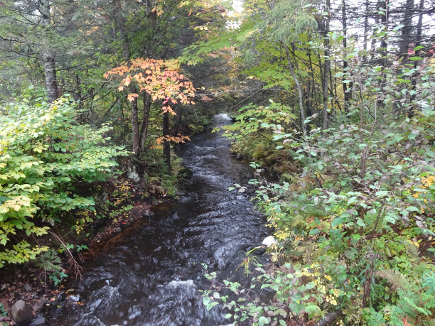

## Passive Sample: Chemical Summary

| Chemical | Class | Fraction of Hits Per Site | Maximum EAR | Number of End Points | Sites With Hits |
| --- | --- | --- | --- | --- | --- |
| Fluorene | PAHs | 0.527272727272727 | 8.92385036799147 | 1 | 29 |
| Aspirin | Pharmaceuticals | 0.290909090909091 | 1.10647304197674 | 1 | 16 |
| Erythromycin | Pharmaceuticals | 0.109090909090909 | 1.68622444260814 | 2 | 6 |
| Naphthalene | PAHs | 0.0727272727272727 | 0.469133803640247 | 1 | 4 |
| Gemfibrozil | Pharmaceuticals | 0.0363636363636364 | 0.294681791866571 | 1 | 2 |
| 1,4-Dichlorobenzene | Other | 0 | 0 | 0 | 0 |
| 4-Octylphenol | Detergent metabolites | 0 | 0 | 0 | 0 |
| Acenaphthene | PAHs | 0 | 0.000340876247474907 | 0 | 0 |
| Acenaphthylene | PAHs | 0 | 0.000785986098061636 | 0 | 0 |
| Acetaminophen | Pharmaceuticals | 0 | 0.0498427019664338 | 0 | 0 |

[output cut: 41 more lines]

## Passive Sample: Site Summary

| Station | Number of Chemicals with Hits | Number End Points | Maximum EAR | Ag [%] | Urban [%] |
| --- | --- | --- | --- | --- | --- |
| IndianaHC | 2 | 2 | 8.92385036799147 | 0.05 | 0.83 |
| Sheboygan | 1 | 1 | 4.52141751978234 | 0.66 | 0.07 |
| Rouge | 2 | 2 | 1.90375474517151 | 0 | 0.92 |
| Cuyahoga | 2 | 2 | 1.68622444260814 | 0.18 | 0.38 |
| Rocky | 2 | 2 | 1.57522864821422 | 0.25 | 0.35 |
| Portage | 2 | 2 | 1.52263298682247 | 0.84 | 0.09 |
| StJoseph | 3 | 3 | 1.14376364388785 | 0.584 | 0.142 |
| GrandOH | 1 | 1 | 1.01136970837237 | 0.34 | 0.09 |
| HuronOH | 1 | 1 | 0.892385036799147 | 0.75 | 0.09 |
| Fox | 2 | 2 | 0.773400365225927 | 0.41 | 0.08 |

[output cut: 45 more lines]

## ToxCast: Comparison of Water Sample and Passive Sample Results

**Color:** Maximum EAR  
**Size:** Number of chemicals with hits

[interactive chart not shown]

## Traditional Benchmarks

| Chemical | Class | Fraction of Sites with Hits | Maximum EAR | Number End Points | Sites with Hits | Total Samples |
| --- | --- | --- | --- | --- | --- | --- |
| Fluoranthene | PAH | 0.526315789473684 | 98.75 | 3 | 30 | 693 |
| Pyrene | PAH | 0.509090909090909 | 116.8 | 2 | 28 | 677 |
| Benzo[a]pyrene | PAH | 0.403508771929825 | 96.4285714285714 | 4 | 23 | 697 |
| Atrazine | Herbicide | 0.298245614035088 | 22.3333333333333 | 3 | 17 | 709 |
| Anthracene | PAH | 0.263157894736842 | 11.6666666666667 | 1 | 15 | 684 |
| Carbaryl | Insecticide | 0.140350877192982 | 2.3 | 4 | 8 | 709 |
| Metolachlor | Herbicide | 0.125 | 0.769230769230769 | 1 | 7 | 704 |
| Phenanthrene | PAH | 0.12280701754386 | 3.625 | 2 | 7 | 700 |
| Dichlorvos | Insecticide | 0.0526315789473684 | 50 | 2 | 3 | 709 |
| Naphthalene | PAH | 0.0175438596491228 | 0.127272727272727 | 1 | 1 | 709 |

[output cut: 14 more lines]

## Traditional Benchmarks: Site Summary

| Station | Hits Per Samples | Total Samples | Number of Chemicals With Hits | Number End Points | Maximum EAR | Ag [%] | Urban [%] |
| --- | --- | --- | --- | --- | --- | --- | --- |
| Clinton | 0.976744186046512 | 43 | 10 | 4 | 116.8 | 0.21 | 0.51 |
| Rouge | 1 | 43 | 7 | 4 | 96.4285714285714 | 0 | 0.92 |
| MilwaukeeMouth | 1 | 45 | 8 | 3 | 30.8 | 0.44 | 0.29 |
| Portage | 0.875 | 64 | 7 | 4 | 22.3333333333333 | 0.84 | 0.09 |
| IndianaHC | 1 | 2 | 5 | 3 | 15.2 | 0.05 | 0.83 |
| StJoseph | 0.96 | 25 | 7 | 3 | 14.8 | 0.584 | 0.142 |
| Cuyahoga | 0.928571428571429 | 28 | 7 | 4 | 13.7931034482759 | 0.18 | 0.38 |
| Maumee | 0.921875 | 64 | 6 | 3 | 5.22222222222222 | 0.79 | 0.1 |
| Burns | 0.967741935483871 | 31 | 7 | 3 | 4.75 | 0.31 | 0.31 |
| Saginaw | 0.903225806451613 | 31 | 6 | 4 | 2.85714285714286 | 0.44 | 0.12 |

[output cut: 47 more lines]